# Univariate Plots Section

In this project, we will be exploring what chemical and physical properties of white wines determine their qualiity. The `wines` dataset (found at [this link](https://www.google.com/url?q=https://s3.amazonaws.com/udacity-hosted-downloads/ud651/wineQualityWhites.csv&sa=D&ust=1487113245445000&usg=AFQjCNGiTBcgJFA2RXpR9o5t2XQ1-pcnow) with the following [description](https://s3.amazonaws.com/udacity-hosted-downloads/ud651/wineQualityInfo.txt)) contains 12 variables with almost 5000 observations. The `X` column is a redundant index, so I do not count it as a unique variable.

```
## [1] 4898   12
```

```
## 'data.frame':    4898 obs. of  12 variables:
##  $ fixed.acidity       : num  7 6.3 8.1 7.2 7.2 8.1 6.2 7 6.3 8.1 ...
##  $ volatile.acidity    : num  0.27 0.3 0.28 0.23 0.23 0.28 0.32 0.27 0.3 0.22 ...
##  $ citric.acid         : num  0.36 0.34 0.4 0.32 0.32 0.4 0.16 0.36 0.34 0.43 ...
##  $ residual.sugar      : num  20.7 1.6 6.9 8.5 8.5 6.9 7 20.7 1.6 1.5 ...
##  $ chlorides           : num  0.045 0.049 0.05 0.058 0.058 0.05 0.045 0.045 0.049 0.044 ...
##  $ free.sulfur.dioxide : num  45 14 30 47 47 30 30 45 14 28 ...
##  $ total.sulfur.dioxide: num  170 132 97 186 186 97 136 170 132 129 ...
##  $ density             : num  1.001 0.994 0.995 0.996 0.996 ...
##  $ pH                  : num  3 3.3 3.26 3.19 3.19 3.26 3.18 3 3.3 3.22 ...
##  $ sulphates           : num  0.45 0.49 0.44 0.4 0.4 0.44 0.47 0.45 0.49 0.45 ...
##  $ alcohol             : num  8.8 9.5 10.1 9.9 9.9 10.1 9.6 8.8 9.5 11 ...
##  $ quality             : int  6 6 6 6 6 6 6 6 6 6 ...
```

```
##  fixed.acidity    volatile.acidity  citric.acid     residual.sugar
##  Min.   : 3.800   Min.   :0.0800   Min.   :0.0000   Min.   : 0.600
##  1st Qu.: 6.300   1st Qu.:0.2100   1st Qu.:0.2700   1st Qu.: 1.700
##  Median : 6.800   Median :0.2600   Median :0.3200   Median : 5.200
##  Mean   : 6.855   Mean   :0.2782   Mean   :0.3342   Mean   : 6.391
##  3rd Qu.: 7.300   3rd Qu.:0.3200   3rd Qu.:0.3900   3rd Qu.: 9.900
##  Max.   :14.200   Max.   :1.1000   Max.   :1.6600   Max.   :65.800
##    chlorides       free.sulfur.dioxide total.sulfur.dioxide
##  Min.   :0.00900   Min.   :  2.00      Min.   :  9.0
##  1st Qu.:0.03600   1st Qu.: 23.00      1st Qu.:108.0
##  Median :0.04300   Median : 34.00      Median :134.0
##  Mean   :0.04577   Mean   : 35.31      Mean   :138.4
##  3rd Qu.:0.05000   3rd Qu.: 46.00      3rd Qu.:167.0
##  Max.   :0.34600   Max.   :289.00      Max.   :440.0
##     density             pH          sulphates         alcohol
##  Min.   :0.9871   Min.   :2.720   Min.   :0.2200   Min.   : 8.00
##  1st Qu.:0.9917   1st Qu.:3.090   1st Qu.:0.4100   1st Qu.: 9.50
##  Median :0.9937   Median :3.180   Median :0.4700   Median :10.40
##  Mean   :0.9940   Mean   :3.188   Mean   :0.4898   Mean   :10.51
##  3rd Qu.:0.9961   3rd Qu.:3.280   3rd Qu.:0.5500   3rd Qu.:11.40
##  Max.   :1.0390   Max.   :3.820   Max.   :1.0800   Max.   :14.20
##     quality
##  Min.   :3.000
##  1st Qu.:5.000
##  Median :6.000
##  Mean   :5.878
##  3rd Qu.:6.000
##  Max.   :9.000
```

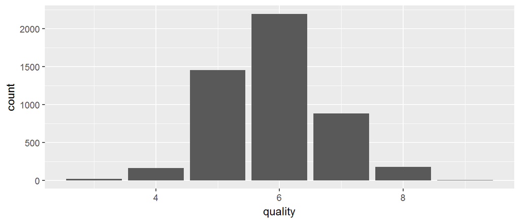

Quality ratings are discrete and run from 3 to 9. Most of them are middling in quality, with a median rating of 6, with very few being rated 9 (5). So many wines are rated 6 that the median and 3rd quartile are the same.

```
##    Min. 1st Qu.  Median    Mean 3rd Qu.    Max.
##   3.000   5.000   6.000   5.878   6.000   9.000
```

```
##
##    3    4    5    6    7    8    9
##   20  163 1457 2198  880  175    5
```

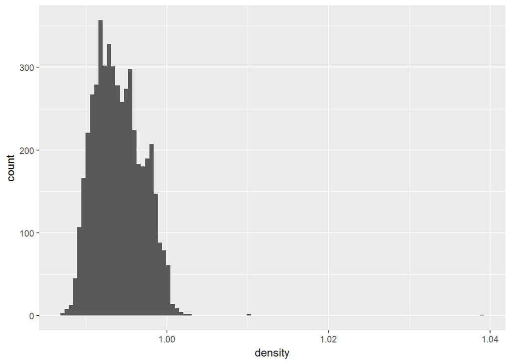

```
##    Min. 1st Qu.  Median    Mean 3rd Qu.    Max.
##  0.9871  0.9917  0.9937  0.9940  0.9961  1.0390
```

There are three major outliers, all corresponding to wines with high sugar content.

```
##      density residual.sugar quality
## 1654 1.01030           31.6       6
## 1664 1.01030           31.6       6
## 2782 1.03898           65.8       6
```

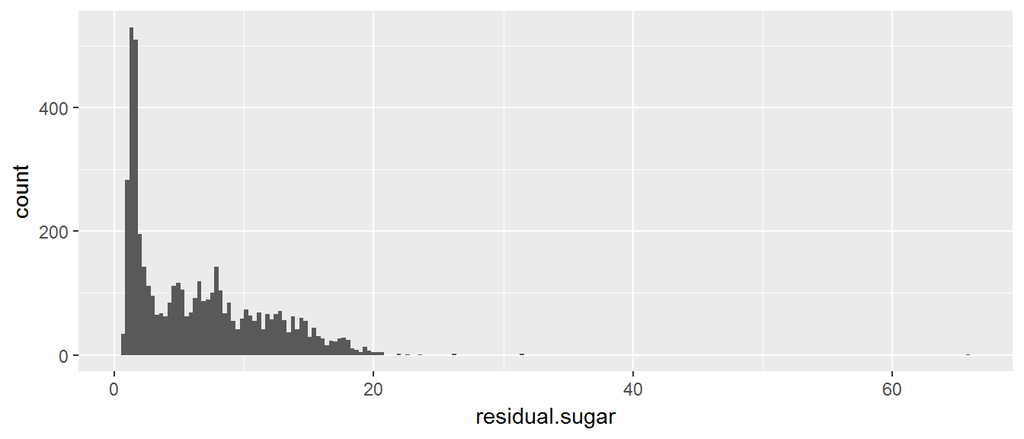

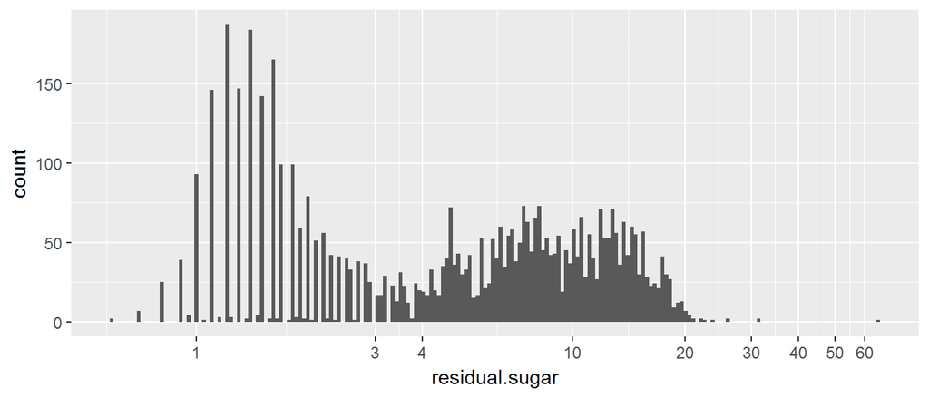

Sugar data seems a bit skewed, so I log-transformed the x-axis, revealing a bimodal distribution with a valley between 3-4 g/dm<sup>3</sup>. So while the high-density outliers have high residual sugar content, the actual shape of the residual sugar distribution differs markedly from that of the density.

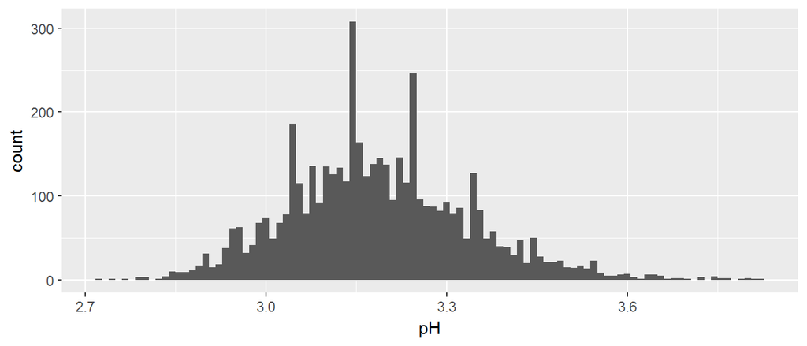

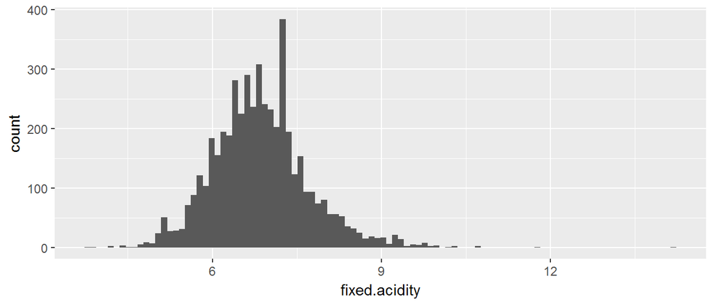

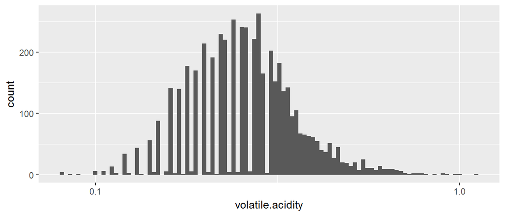

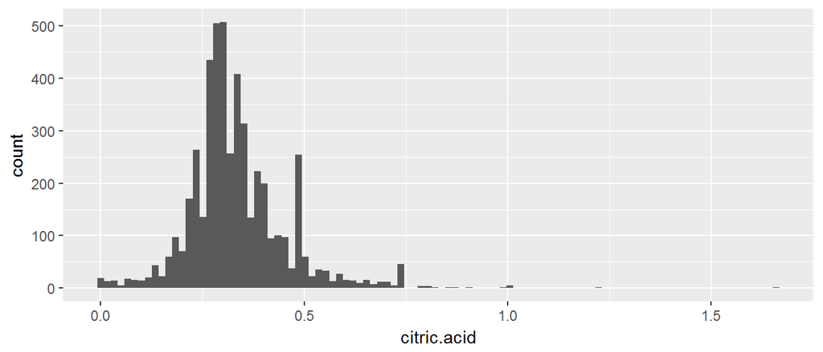

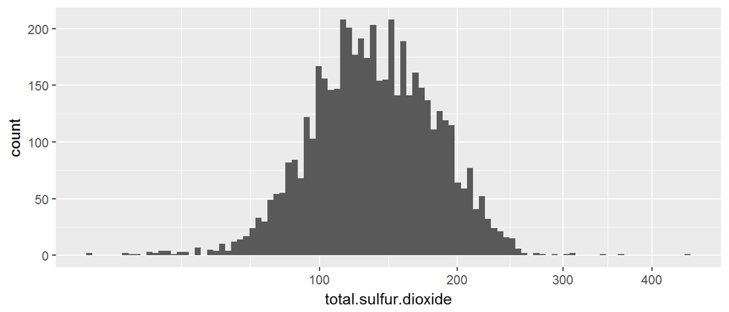

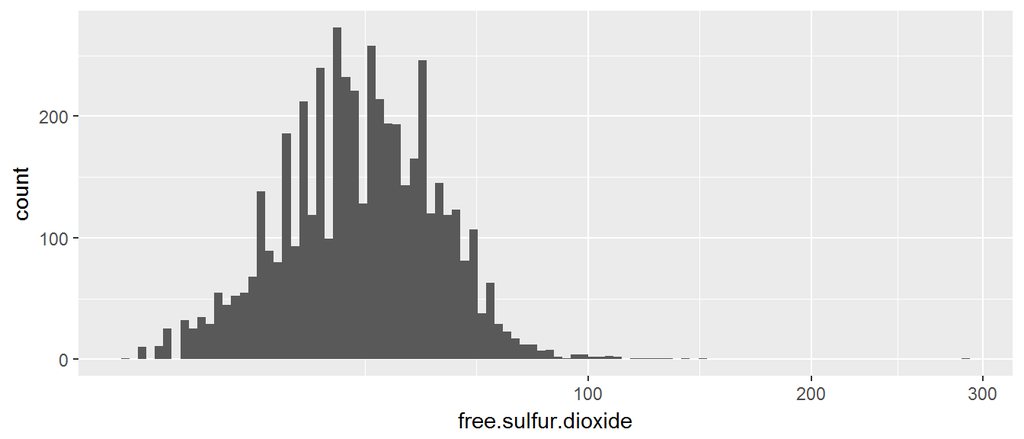

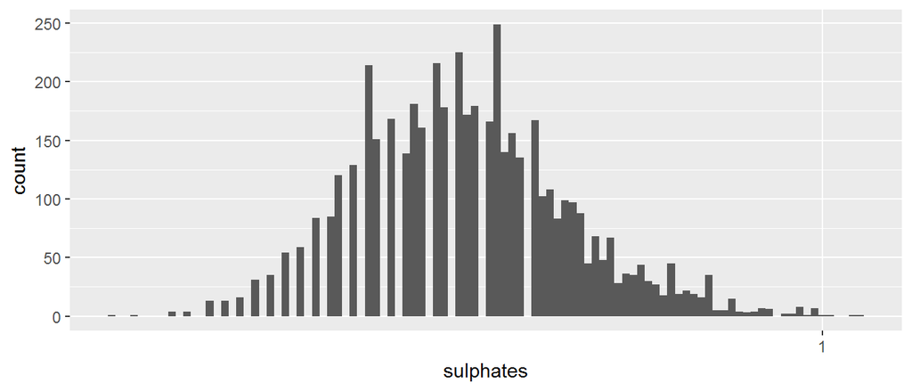

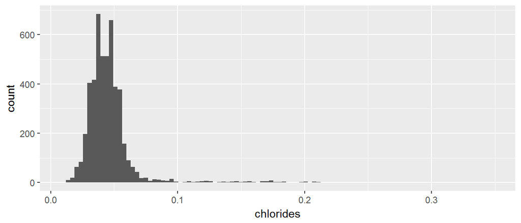

All of these chemical properties fall on normal distributions, with the exception of `volatile.acidity` and `sulphates`, which are log-transformed, and `total.sulfur.dioxide` and `free.sulfur.dioxide`, which are square-root-transformed.

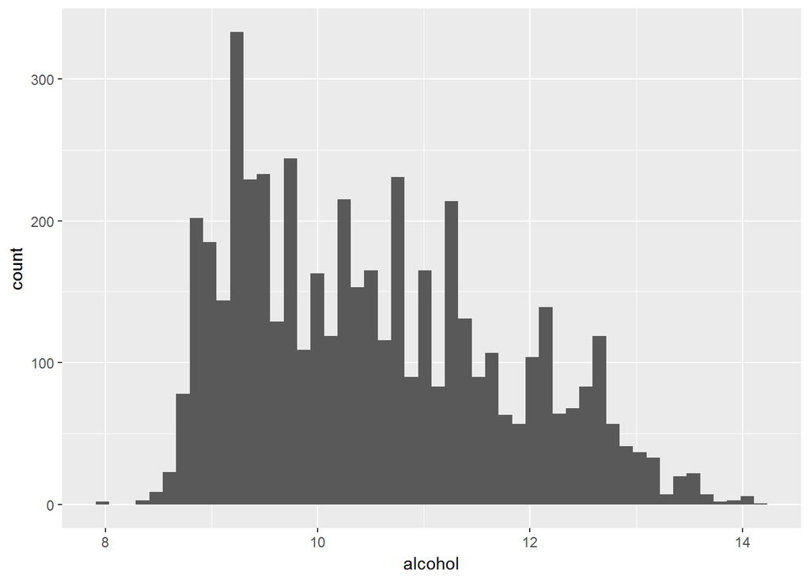

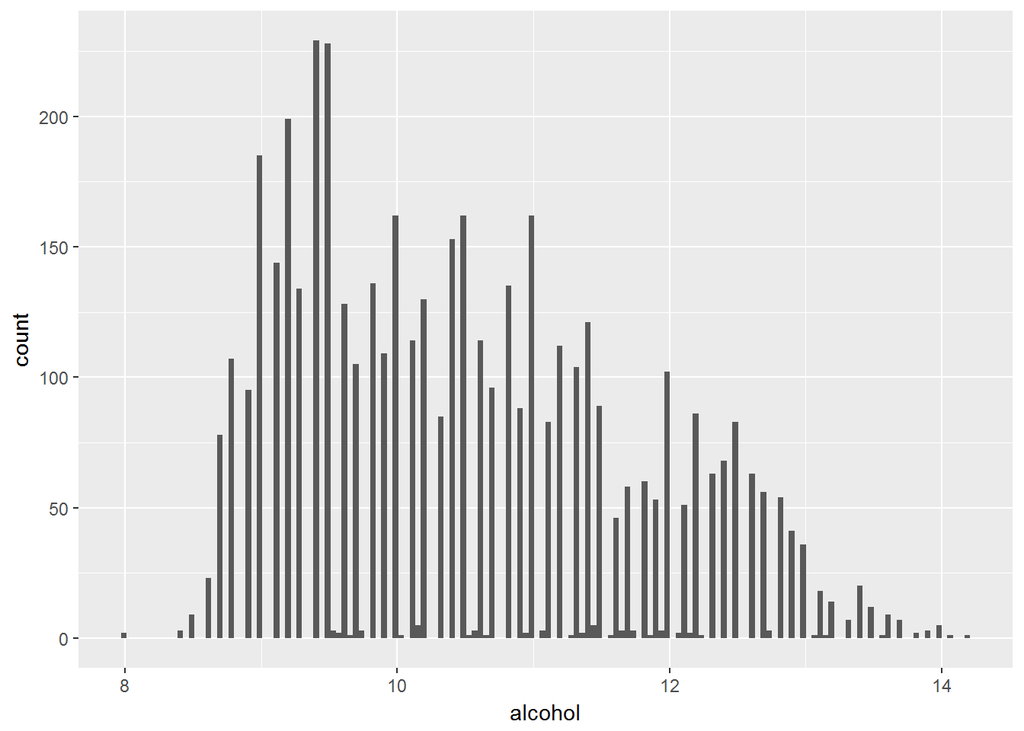

```
##
## 10.0333333333333             10.1 10.1333333333333            10.15
##                1              114                2                3
##             10.2             10.3             10.4 10.4666666666667
##              130               85              153                2
##             10.5 10.5333333333333            10.55 10.5666666666667
##              160                1                2                1
##             10.6            10.65             10.7             10.8
##              114                1               96              135
##             10.9 10.9333333333333 10.9666666666667            10.98
##               88                2                3                1
```

```
##    Min. 1st Qu.  Median    Mean 3rd Qu.    Max.
##    8.00    9.50   10.40   10.51   11.40   14.20
```

The `alcohol` content in wines have a slightly right-skewed distribution. Most of the alcohol counts have three significant figures (e.g. 10.3), with decimals ending in the tenths place. This explains the gaps in the distribution.

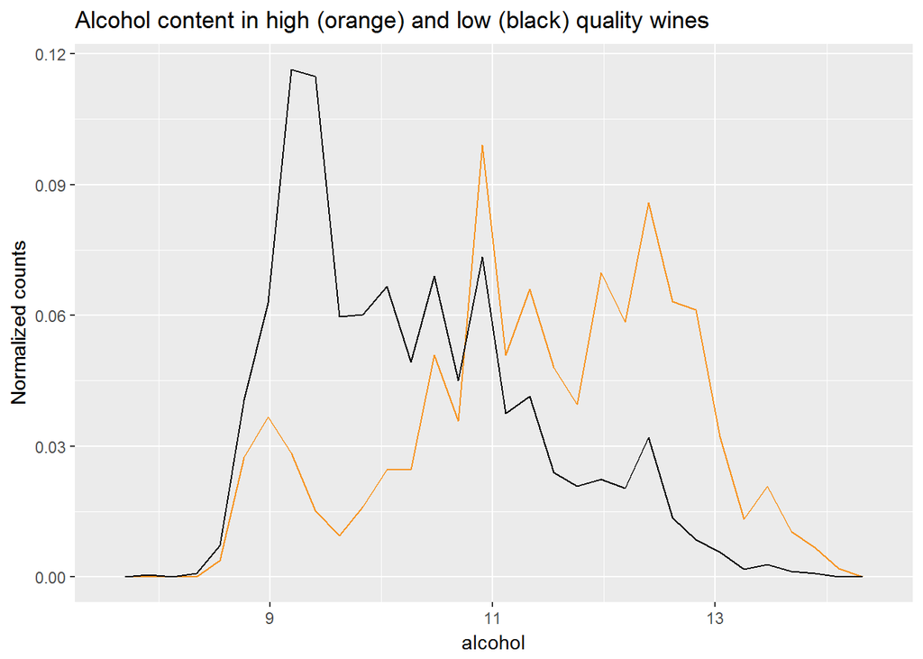

In the above frequency polygon, it looks like there tends to be more alcohol content in high (`quality > 6` in orange) vs low quality (`quality <= 6` in black) wines. Let’s try looking at high to low comparisons for other features:

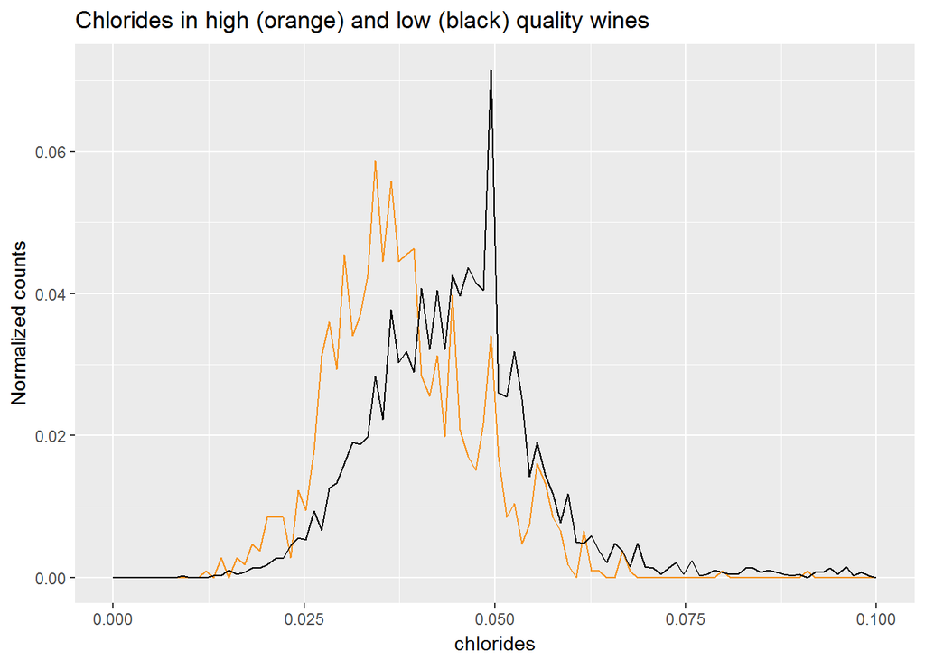

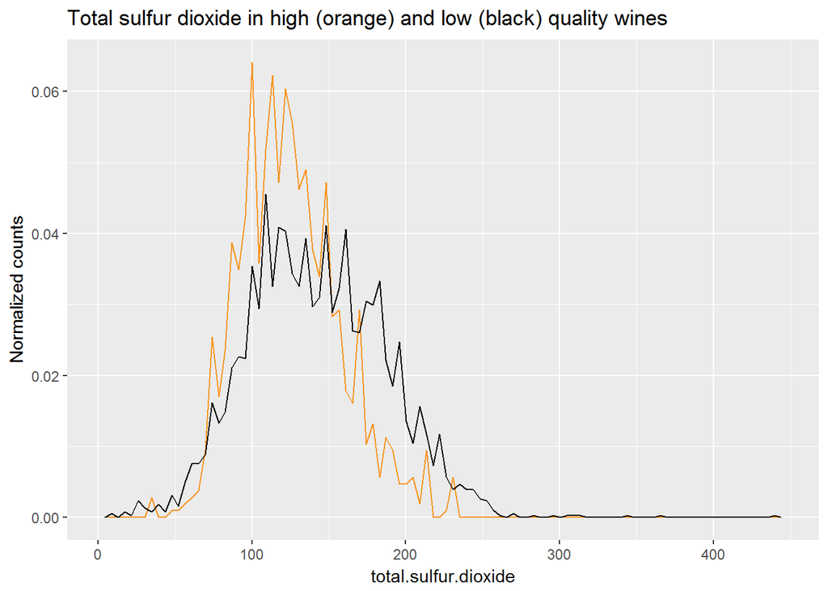

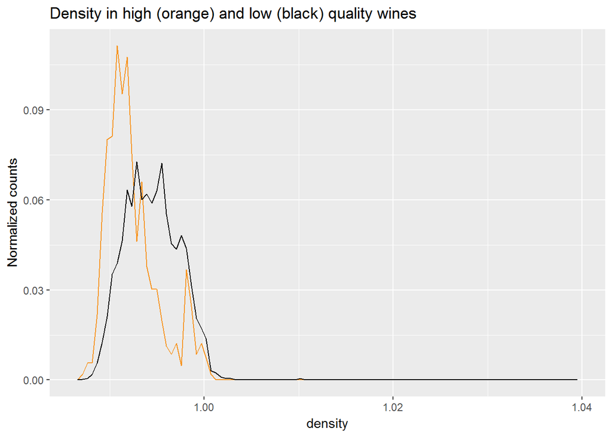

```
##    Min. 1st Qu.  Median    Mean 3rd Qu.    Max.
##   4.130   6.890   7.405   7.467   7.960  14.960
```

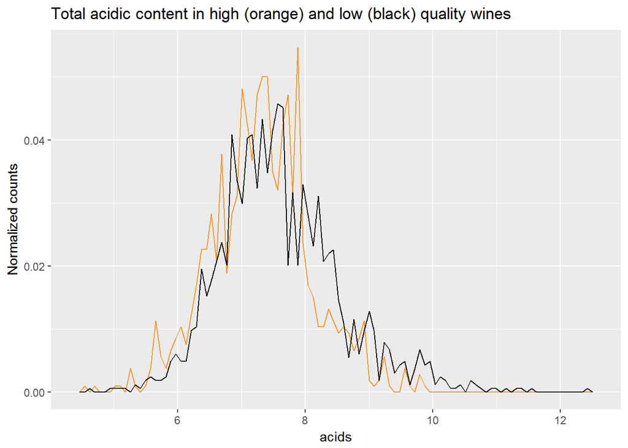

Alas, there seems to be no meaningful difference.

High-quality wines tend to have lower density than low-quality wines, which suggests that a combination of high alcohol content and low residual sugar wines will have lower density and will more likely be a higher quality wine.

There are only 5 white wines that have a quality rating of 9. Let’s take a look at their features:

```
##      fixed.acidity volatile.acidity citric.acid residual.sugar chlorides
## 775            9.1             0.27        0.45           10.6     0.035
## 821            6.6             0.36        0.29            1.6     0.021
## 828            7.4             0.24        0.36            2.0     0.031
## 877            6.9             0.36        0.34            4.2     0.018
## 1606           7.1             0.26        0.49            2.2     0.032
##      free.sulfur.dioxide total.sulfur.dioxide density   pH sulphates
## 775                   28                  124 0.99700 3.20      0.46
## 821                   24                   85 0.98965 3.41      0.61
## 828                   27                  139 0.99055 3.28      0.48
## 877                   57                  119 0.98980 3.28      0.36
## 1606                  31                  113 0.99030 3.37      0.42
##      alcohol quality acids
## 775     10.4       9  9.82
## 821     12.4       9  7.25
## 828     12.5       9  8.00
## 877     12.7       9  7.60
## 1606    12.9       9  7.85
```

This sample size is much too small to make meaningful generalizations, but these quality 9 wines tend to have low density and above average alcoholic content (with the exception of the first one, which also has high sugar content). Combining this with the above plots of high vs. low quality wines, it seems like high quality wines have low quantities of salts, sulfur, and sugar, and yet still have an above-average alcohol percentage.

# Univariate Analysis

### What is the structure of your dataset?

There are 4,898 white wines in the dataset with 12 features:

1. `fixed.acidity`: fixed acidity (tartaric acid content) in g/dm<sup>3</sup>
2. `volatile.acidity`: volatile acidity (acetic acid content) in g/dm<sup>3</sup>
3. `citric.acid`: citric acid content (“freshness”) in g/dm<sup>3</sup>
4. `residual.sugar`: residual sugar content (“sweetness”) in g/dm<sup>3</sup>
5. `chlorides`: chloride content (salts) in g/dm<sup>3</sup>
6. `free.sulfur.dioxide`: free sulfur dioxide content (prevents microbial growth and oxidation) in mg/dm<sup>3</sup>
7. `total.sulfur.dioxide`: total sulfur dioxide content in mg/dm<sup>3</sup>
8. `density`: density (g/cm<sup>3</sup>)
9. `pH`: pH (0 = very acidic —-> 14 = very basic)
10. `sulphates`: sulphate content (K<sub>2</sub>SO<sub>4</sub>) in g/dm<sup>3</sup>
11. `alcohol`: percent alcohol
12. `quality`: quality (0 = bad —-> 10 = good)

With the exception of `quality`, each of these features are floating-point numerical values. The `quality` variable is an integer quantity, but for our purposes it may be converted to an ordered factor variable as there are only 7 possible values for `quality` in the data (3 through 9).

Stray observations:

- Almost half (2,198) of white wines have a quality rating of 6.
- Only 5 wines have the maximum quality rating of 9 in this dataset.
- 98% percent of white wines are less dense than water (water has a density of 1 g/cm<sup>3</sup>.
- The average density is 0.994 g/cm<sup>3</sup>
- The average pH is 3.188 (for reference, the pH of pure distilled water is 7.0)

### What is/are the main feature(s) of interest in your dataset?

The main feature of interest is `quality`. Many of the other features contribute to either the pH or density of a given wine. Therefore it would be good to see how `pH` and `density` affect the quality.

### What other features in the dataset do you think will help support your investigation into your feature(s) of interest?

Other features where we see some divergence between low and high quality wines are `chlorides`, `total.sulfur.dioxide`, and `alcohol`, alongside the more general `pH` and `density` features.

### Did you create any new variables from existing variables in the dataset?

I’ve tried consolidating the `fixed.acidity`, `volatile.acidity`, and `citric.acid` into a new feature called `acids`, but so far I haven’t seen any many differences between high and low quality wines with this feature.

### Of the features you investigated, were there any unusual distributions? Did you perform any operations on the data to tidy, adjust, or change the form of the data? If so, why did you do this?

Although I had to log-transform or square root transform some of the plots, all except the `residual.sugar` and `alcohol` plots tend to look like normal distributions. The distribution of sugars appears bi-modal, perhaps even tri-modal, with a large peak at 1.5 g/dm<sup>3</sup> and two smaller peaks straddling the 10 g/dm<sup>3</sup> point. The histogram for alcohol content is right-skewed, with half of wines containing less than 10.4% alcohol. However, wines with quality rating greater than 6 have an alcohol distribution that is left-skewed, with half of wines containing more than 11.5% alcohol.

# Bivariate Plots Section

```
##                      fixed.acidity volatile.acidity citric.acid
## fixed.acidity                 1.00            -0.02        0.29
## volatile.acidity             -0.02             1.00       -0.15
## citric.acid                   0.29            -0.15        1.00
## residual.sugar                0.09             0.06        0.09
## chlorides                     0.02             0.07        0.11
## free.sulfur.dioxide          -0.05            -0.10        0.09
## total.sulfur.dioxide          0.09             0.09        0.12
## density                       0.27             0.03        0.15
## pH                           -0.43            -0.03       -0.16
## sulphates                    -0.02            -0.04        0.06
## alcohol                      -0.12             0.07       -0.08
## quality                      -0.11            -0.19       -0.01
##                      residual.sugar chlorides free.sulfur.dioxide
## fixed.acidity                  0.09      0.02               -0.05
## volatile.acidity               0.06      0.07               -0.10
## citric.acid                    0.09      0.11                0.09
## residual.sugar                 1.00      0.09                0.30
## chlorides                      0.09      1.00                0.10
## free.sulfur.dioxide            0.30      0.10                1.00
## total.sulfur.dioxide           0.40      0.20                0.62
## density                        0.84      0.26                0.29
## pH                            -0.19     -0.09                0.00
## sulphates                     -0.03      0.02                0.06
## alcohol                       -0.45     -0.36               -0.25
## quality                       -0.10     -0.21                0.01
##                      total.sulfur.dioxide density    pH sulphates alcohol
## fixed.acidity                        0.09    0.27 -0.43     -0.02   -0.12
## volatile.acidity                     0.09    0.03 -0.03     -0.04    0.07
## citric.acid                          0.12    0.15 -0.16      0.06   -0.08
## residual.sugar                       0.40    0.84 -0.19     -0.03   -0.45
## chlorides                            0.20    0.26 -0.09      0.02   -0.36
## free.sulfur.dioxide                  0.62    0.29  0.00      0.06   -0.25
## total.sulfur.dioxide                 1.00    0.53  0.00      0.13   -0.45
## density                              0.53    1.00 -0.09      0.07   -0.78
## pH                                   0.00   -0.09  1.00      0.16    0.12
## sulphates                            0.13    0.07  0.16      1.00   -0.02
## alcohol                             -0.45   -0.78  0.12     -0.02    1.00
## quality                             -0.17   -0.31  0.10      0.05    0.44
##                      quality
## fixed.acidity          -0.11
## volatile.acidity       -0.19
## citric.acid            -0.01
## residual.sugar         -0.10
## chlorides              -0.21
## free.sulfur.dioxide     0.01
## total.sulfur.dioxide   -0.17
## density                -0.31
## pH                      0.10
## sulphates               0.05
## alcohol                 0.44
## quality                 1.00
```

To better illustrate the correlations between features, let’s construct a heat map of the most correlated features.

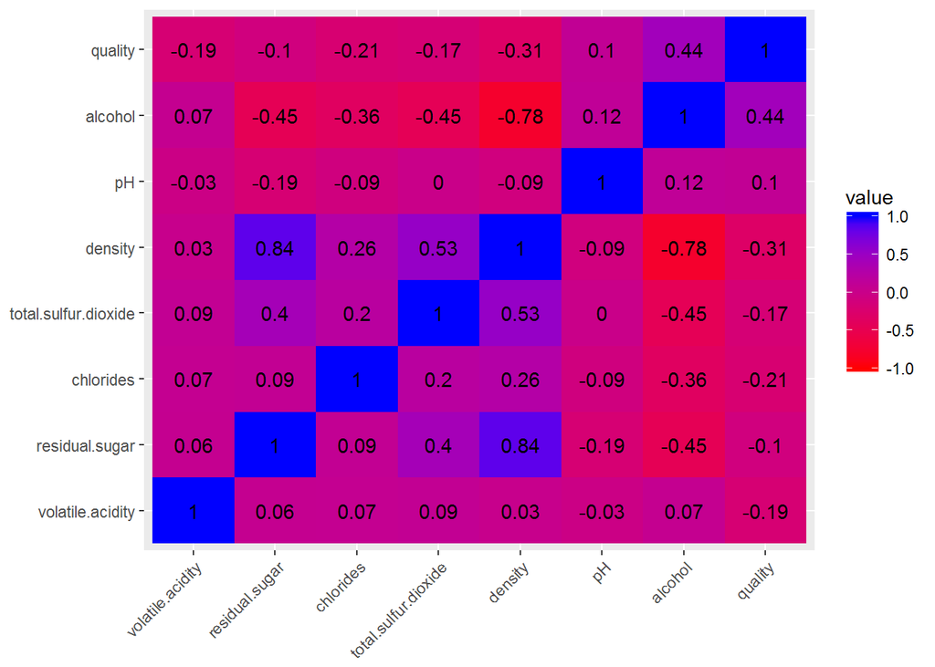

The factors that are most correlated to quality are `alcohol` and `density`. Below is a pairwise plot matrix of the eight features plotted in the heatmap, after converting the `quality` variable into an ordered factor called `quality_factors`.

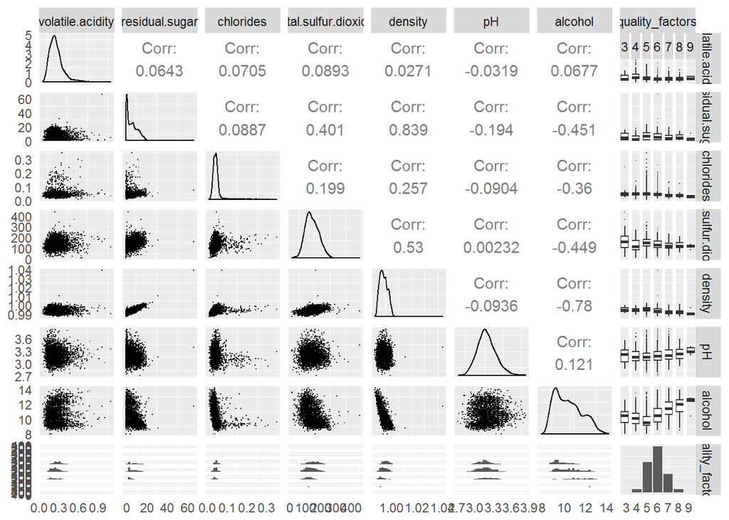

Let’s take a closer look at some features and how they affect quality.

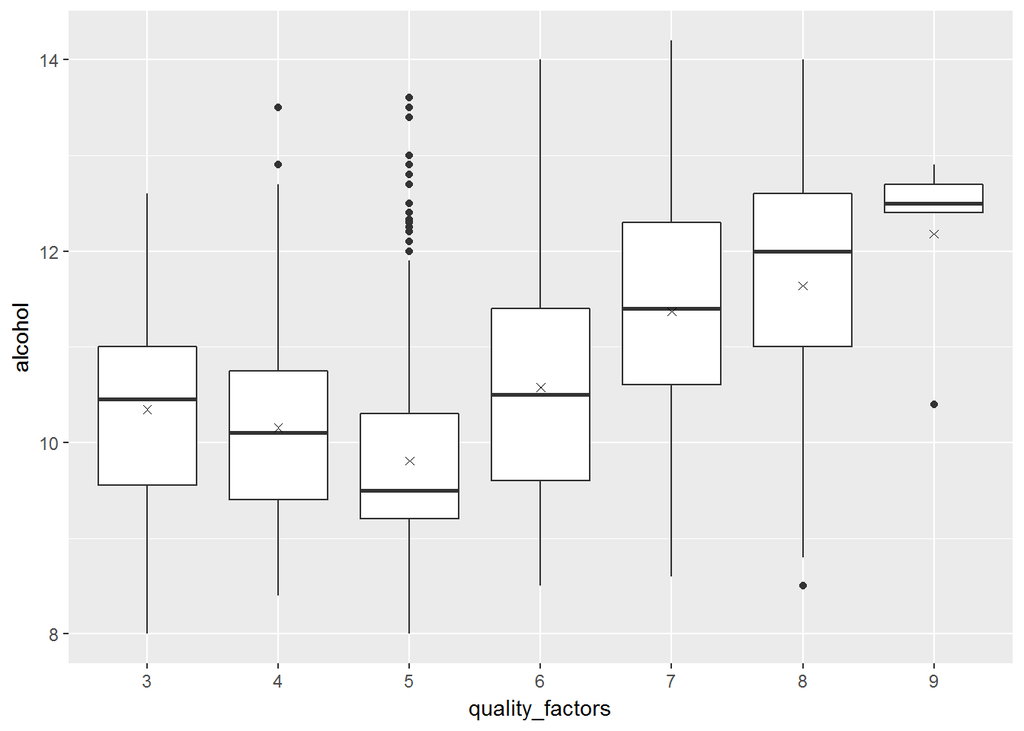

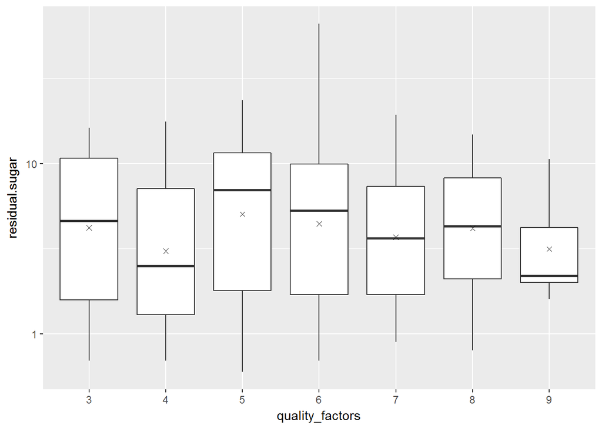

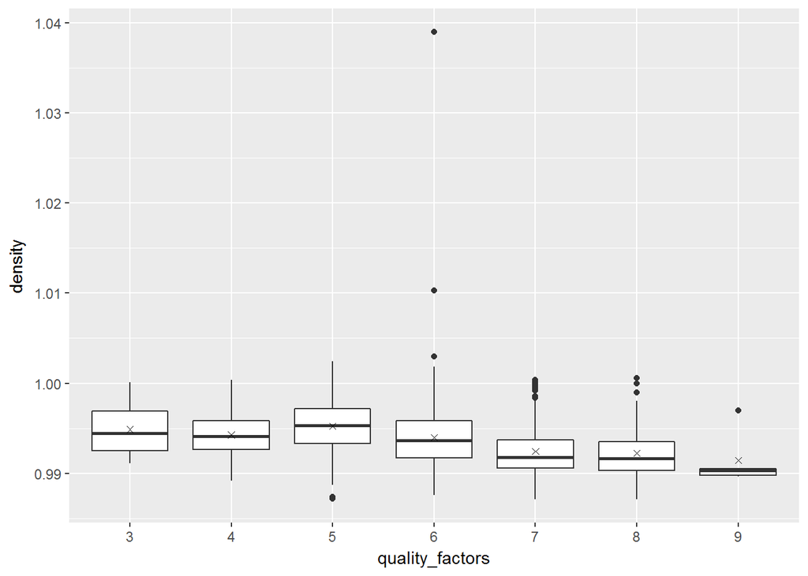

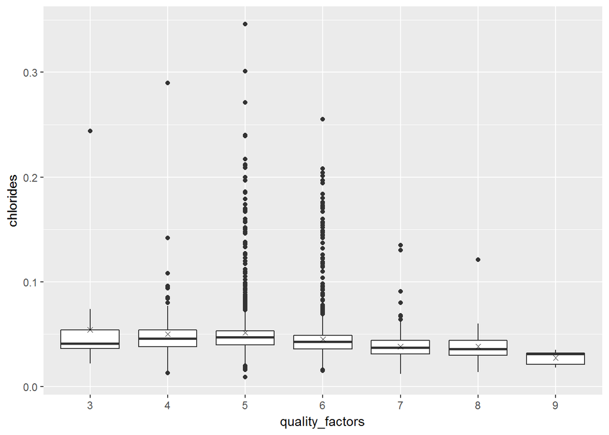

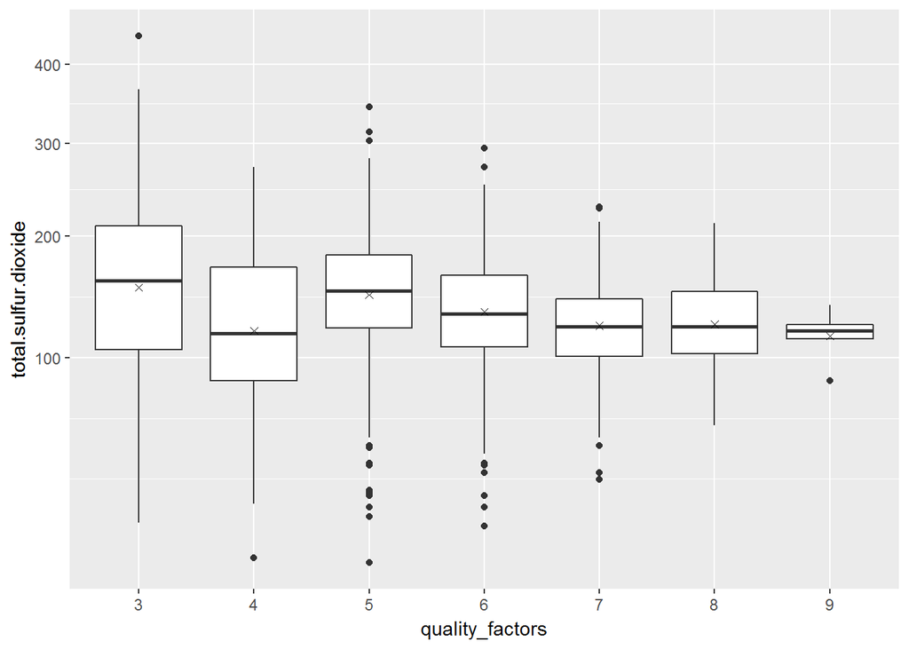

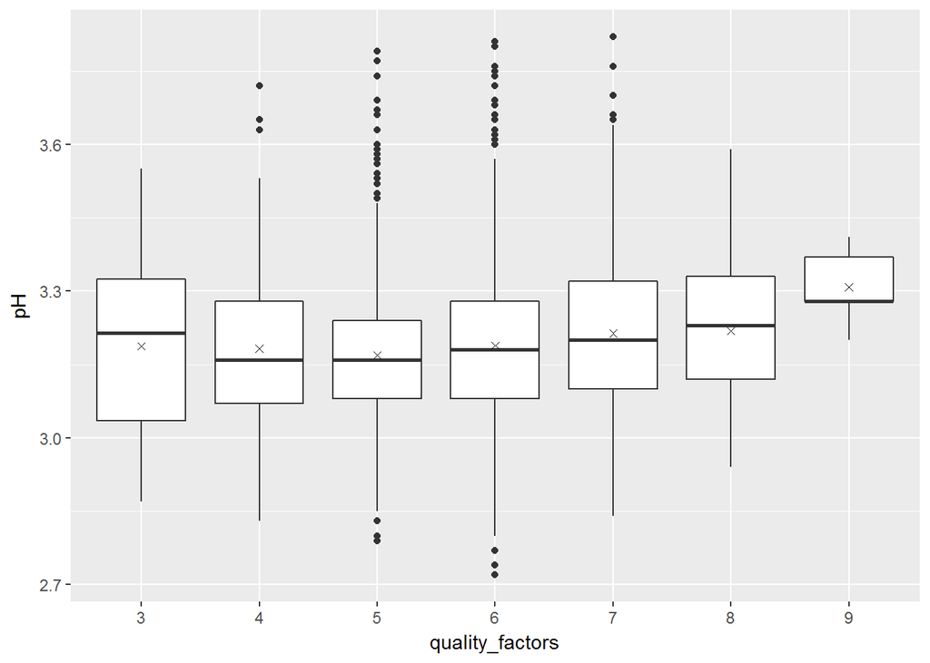

With the exception of `alcohol` and `pH`, for wines rated 5 or higher, a smaller quantity of the feature involved will produce a better quality wine, but only weakly.

First looking at `alcohol`, we see that the average alcohol percentage increases for wines rated 5 or better. There are two noticable outliers for quality 8 and 9 wines though, having very low alcohol content with respect to the average of their grade.

As for `density`, there’s a negative relationship, as the average density tend to go downward with increasing quality. There are three large outliers for wines rated 6. As we’ve seen above, this is due to a high sugar level in those particular wines. Let’s check this by plotting all 6-rated wines with densities greater than 1 g/cm<sup>3</sup>.

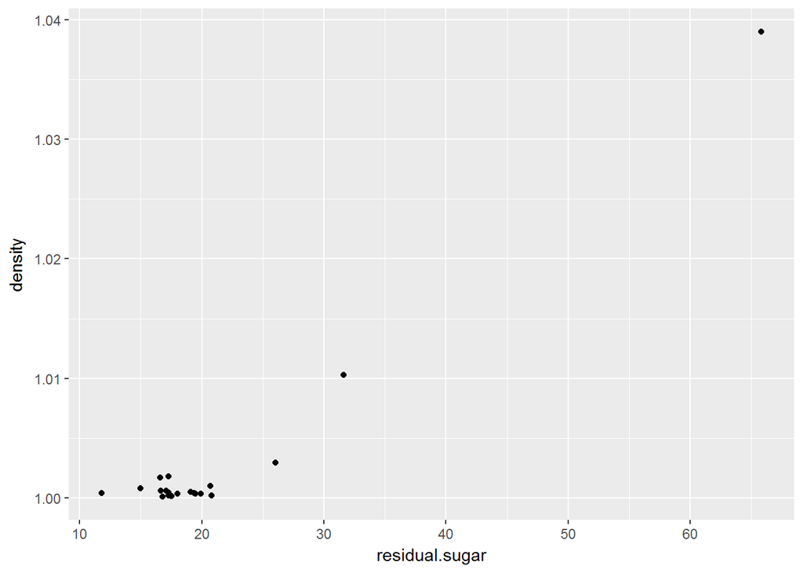

As suspected, the more sugar a wine has, the greater its density, considering the greater density of sugar compared to alcohol or water. Here’s the general trend.

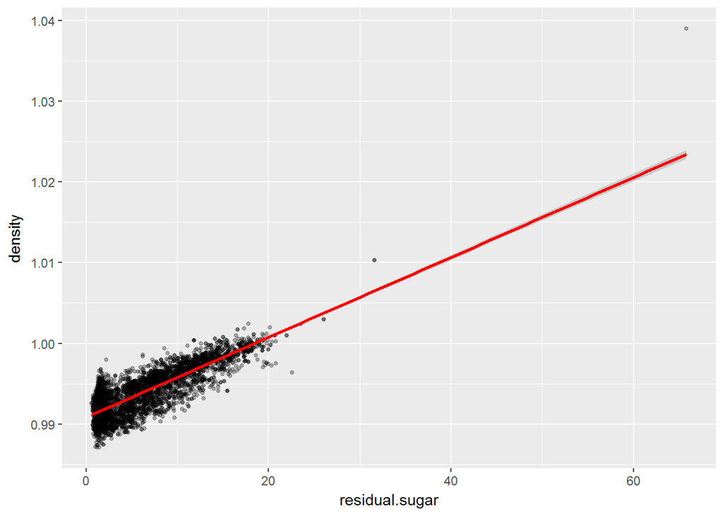

The trend is quite linear. This is to be expected because we’ve already seen that the density and residual sugar are highly correlated.

```
##
## Call:
## lm(formula = density ~ residual.sugar, data = wines)
##
## Residuals:
##        Min         1Q     Median         3Q        Max
## -0.0056862 -0.0011059  0.0001726  0.0011523  0.0155617
##
## Coefficients:
##                 Estimate Std. Error t value Pr(>|t|)
## (Intercept)    9.909e-01  3.742e-05 26480.7   <2e-16 ***
## residual.sugar 4.947e-04  4.586e-06   107.9   <2e-16 ***
## ---
## Signif. codes:  0 '***' 0.001 '**' 0.01 '*' 0.05 '.' 0.1 ' ' 1
##
## Residual standard error: 0.001628 on 4896 degrees of freedom
## Multiple R-squared:  0.7039, Adjusted R-squared:  0.7038
## F-statistic: 1.164e+04 on 1 and 4896 DF,  p-value: < 2.2e-16
```

Residual sugar alone accounts for over 70% of the variance in the density. Similarly, alcohol content and total sulfur dioxide also affect the density of wines.

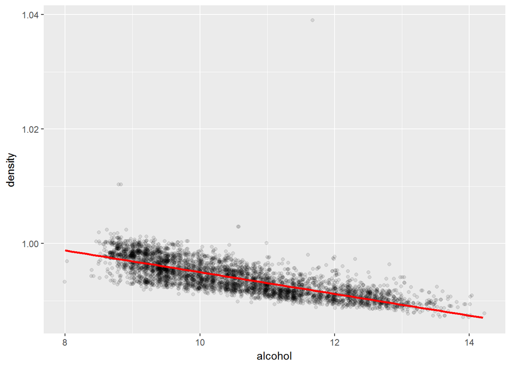

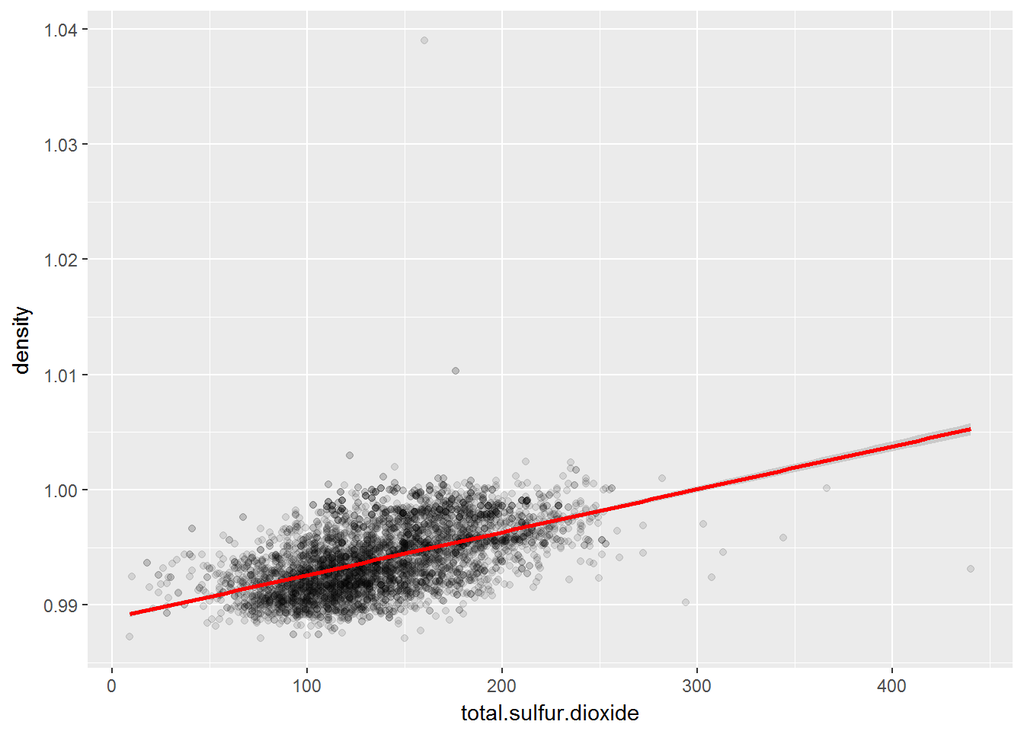

As we’ve seen before, the outliers are affected by the residual sugar in the wine, yet still the density has a linear dependence on the alcohol content and total sulfur dioxide. In the multivariate plots section, we will explore how both alcohol and sugar content affect the density.